# The Euler-Lotka Equation: Derivation and Application

MBE 713 - Population Dynamics

2026-09-07

## Introduction

The Euler-Lotka Equation is one of the most important equations in demographic ecology. It provides the mathematical foundation for linking life table data (age-specific survival and fertility) to the intrinsic rate of population increase (λ or r). In this tutorial, we will derive this equation from first principles and demonstrate its application.

## Part 1: Foundation Concepts

### Birth and Death Rates Over Time

Let’s consider a population where births and deaths occur continuously. At time $t = 0$, we have a cohort of newborns. As time progresses:

- Some individuals survive to reproductive age
- Those that survive produce offspring
- Offspring then grow up and reproduce

### Defining Key Variables

Let’s define:

- $l_x$ = Probability that an individual survives from birth to age $x$ (survivorship function)
- $m_x$ = Age-specific fertility rate (number of female offspring per female of age $x$)
- $\lambda$ = Finite rate of increase (population multiplier per time unit)
- $r$ = Intrinsic rate of increase, where $\lambda = e^r$
- $x$ = Age class
- $a$ = Age at reproduction (typically starting from 0 or 1 depending on convention)

## Part 2: Derivation of the Euler-Lotka Equation

### Step 1: Counting Offspring From a Birth Cohort

Consider a cohort of $N_0$ newborn females at time $t = 0$.

At age $x$: - The number of females still alive is $N_x = N_0 \cdot l_x$ - Each of these females produces $m_x$ offspring

So the total number of offspring produced by this cohort at age $x$ is:
$$\text{Offspring at age } x = N_0 \cdot l_x \cdot
m_x$$

### Step 2: Discount Back to Present Value

In a population growing at a constant rate $\lambda$, offspring born at time $t = x$ are worth only $\lambda^{-x}$ relative to newborns at time $t = 0$.

Alternatively, if using the continuous-time version with the intrinsic rate $r$, each offspring born at age $x$ is discounted by factor $e^{-rx}$.

Therefore, the “reproductive value” of a female’s offspring at age $x$, measured at time 0, is:
$$\text{Reproductive Value} = l_x \cdot m_x \cdot
\lambda^{-x}$$

or in continuous time:
$$\text{Reproductive Value} = l_x \cdot m_x \cdot
e^{-rx}$$

### Step 3: Sum Across All Ages

The total reproductive output of a female (summed across all reproductive ages) must equal exactly 1 (in a stable population) for the population to replace itself with rate $\lambda$.

This is because each newborn female must, on average, produce exactly one female offspring that survives to replacement level in a stable population.

**This is the Euler-Lotka Equation:**

$$1 = \sum_{x=0}^{\infty} e^{-rx} l_x
m_x$$

Or using the discrete form with $\lambda$:

$$1 = \sum_{x=0}^{\infty} \lambda^{-x} l_x
m_x$$

### Step 4: Understanding the Equation

Breaking down what this equation means:

- **$e^{-rx}$**: Discounts future offspring to present value (intrinsic rate perspective)
- **$l_x$**: Only survivors reproduce
- **$m_x$**: Counts how many offspring each survivor produces
- **$\sum$**: We sum across all ages to get lifetime reproductive output
- **$= 1$**: In a stable population, lifetime reproductive output equals 1

## Part 3: Solving the Euler-Lotka Equation

The Euler-Lotka Equation is typically **transcendental** (cannot be solved algebraically). We must solve it numerically to find $r$.

### Example: A Simple Life Table

Let’s create a hypothetical example with life table and fertility data:

```r
# Create life table and fertility data
life_table <- tibble(
  age = 0:5,
  lx = c(1.0, 0.8, 0.6, 0.4, 0.2, 0.0),  # Probability of surviving to age x
  mx = c(0.0, 1.5, 2.0, 1.2, 0.5, 0.0)   # Female offspring per female
)

print("Life Table:")
```

```
## [1] "Life Table:"
```

```r
print(life_table)
```

```
## # A tibble: 6 × 3
##     age    lx    mx
##   <int> <dbl> <dbl>
## 1     0   1     0
## 2     1   0.8   1.5
## 3     2   0.6   2
## 4     3   0.4   1.2
## 5     4   0.2   0.5
## 6     5   0     0
```

### Solving the Euler-Lotka Equation Numerically

We need to find the value of $r$ such that:
$$\sum_{x=0}^{5} e^{-rx} l_x m_x =
1$$

```r
# Define the Euler-Lotka equation
euler_lotka <- function(r, lx, mx) {
  x <- 0:(length(lx) - 1)
  sum(exp(-r * x) * lx * mx) - 1
}

# Create a function to solve for r
solve_euler_lotka <- function(lx, mx, r_range = c(-0.5, 1)) {
  result <- uniroot(euler_lotka, interval = r_range,
                    lx = lx, mx = mx)
  return(result$root)
}

# Solve for r
r_intrinsic <- solve_euler_lotka(life_table$lx, life_table$mx)
lambda <- exp(r_intrinsic)

cat("Intrinsic rate of increase (r):", round(r_intrinsic, 4), "\n")
```

```
## Intrinsic rate of increase (r): 0.6696
```

```r
cat("Finite rate of increase (λ):", round(lambda, 4), "\n")
```

```
## Finite rate of increase (λ): 1.9535
```

### Verify the Solution

Let’s verify that our solution is correct:

```r
# Verify: Calculate left side of equation with our r value
verification <- sum(exp(-r_intrinsic * life_table$age) *
                    life_table$lx * life_table$mx)

cat("Verification (should equal 1):", round(verification, 6), "\n")
```

```
## Verification (should equal 1): 0.999996
```

```r
# Calculate generation time
R0 <- sum(life_table$lx * life_table$mx)  # Net reproductive rate
T <- sum(life_table$age * life_table$lx * life_table$mx) / R0  # Generation time

cat("\nNet reproductive rate (R0):", round(R0, 4), "\n")
```

```
##
## Net reproductive rate (R0): 2.98
```

```r
cat("Generation time (T):", round(T, 4), "time units\n")
```

```
## Generation time (T): 1.8255 time units
```

```r
cat("Relationship check: r ≈ ln(R0)/T =", round(log(R0)/T, 4), "\n")
```

```
## Relationship check: r ≈ ln(R0)/T = 0.5981
```

## Part 4: Visualization

### Plot the Euler-Lotka Function

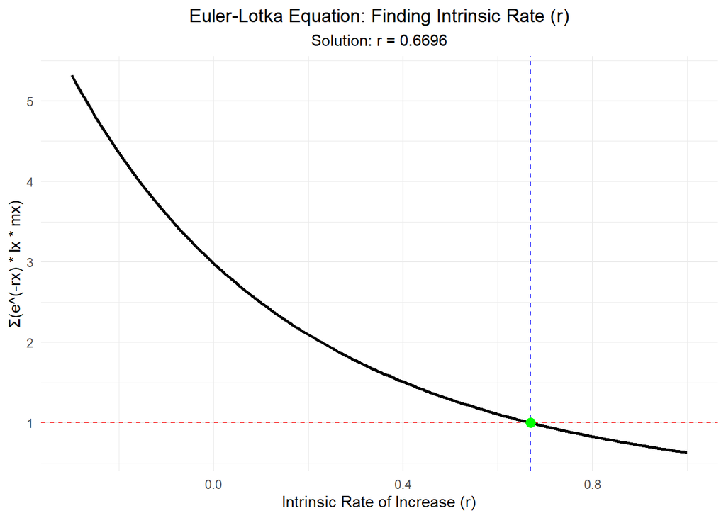

```r
# Create a range of r values and calculate the left side of the equation
r_values <- seq(-0.3, 1, by = 0.01)
euler_values <- sapply(r_values, function(r) {
  sum(exp(-r * life_table$age) * life_table$lx * life_table$mx)
})

# Create the plot
p1 <- ggplot(data.frame(r = r_values, euler = euler_values),
             aes(x = r, y = euler)) +
  geom_line(size = 1) +
  geom_hline(yintercept = 1, linetype = "dashed", color = "red", alpha = 0.7) +
  geom_vline(xintercept = r_intrinsic, linetype = "dashed", color = "blue", alpha = 0.7) +
  geom_point(aes(x = r_intrinsic, y = 1), color = "green", size = 3) +
  labs(title = "Euler-Lotka Equation: Finding Intrinsic Rate (r)",
       x = "Intrinsic Rate of Increase (r)",
       y = "Σ(e^(-rx) * lx * mx)",
       subtitle = paste("Solution: r =", round(r_intrinsic, 4))) +
  theme_minimal() +
  theme(plot.title = element_text(hjust = 0.5),
        plot.subtitle = element_text(hjust = 0.5))

print(p1)
```

### Visualize Survivorship and Fertility

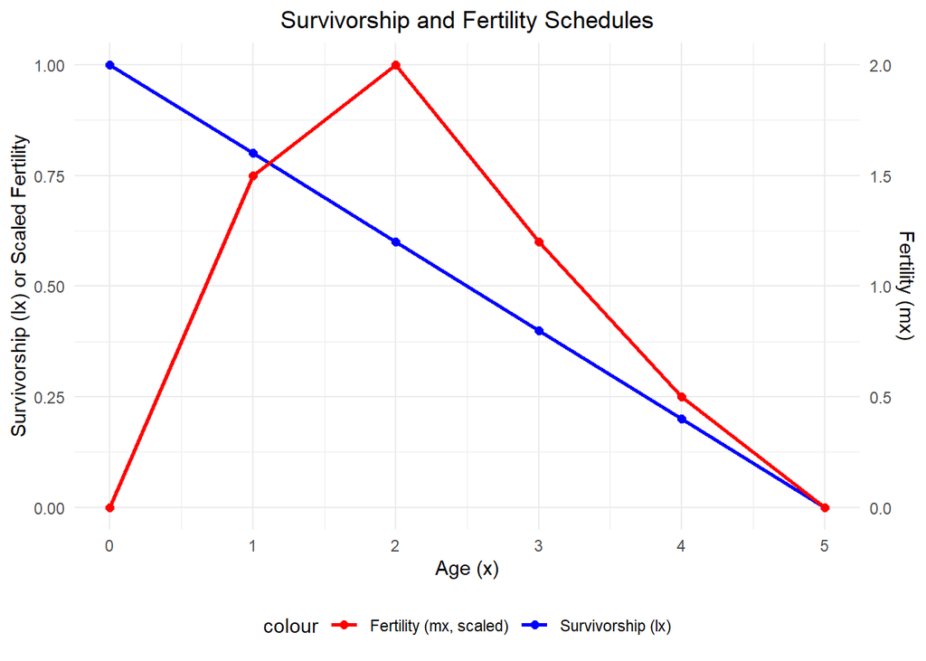

```r
# Create a combined plot of lx and mx
p2 <- ggplot(life_table, aes(x = age)) +
  geom_line(aes(y = lx, color = "Survivorship (lx)"), size = 1) +
  geom_point(aes(y = lx, color = "Survivorship (lx)"), size = 2) +
  geom_line(aes(y = mx/max(mx), color = "Fertility (mx, scaled)"), size = 1) +
  geom_point(aes(y = mx/max(mx), color = "Fertility (mx, scaled)"), size = 2) +
  scale_y_continuous("Survivorship (lx) or Scaled Fertility",
                     sec.axis = sec_axis(~. * max(life_table$mx), name = "Fertility (mx)")) +
  scale_color_manual(values = c("Survivorship (lx)" = "blue",
                                "Fertility (mx, scaled)" = "red")) +
  labs(title = "Survivorship and Fertility Schedules",
       x = "Age (x)") +
  theme_minimal() +
  theme(plot.title = element_text(hjust = 0.5),
        legend.position = "bottom")

print(p2)
```

### Reproductive Value Through Time

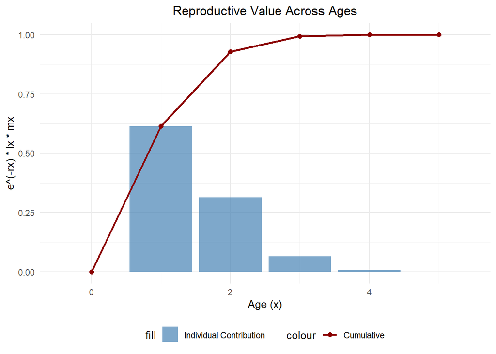

```r
# Calculate reproductive value at each age
life_table <- life_table %>%
  mutate(
    reproductive_value = lx * mx * exp(-r_intrinsic * age),
    cumulative_value = cumsum(reproductive_value)
  )

p3 <- ggplot(life_table, aes(x = age)) +
  geom_bar(aes(y = reproductive_value, fill = "Individual Contribution"),
           stat = "identity", alpha = 0.7) +
  geom_line(aes(y = cumulative_value, color = "Cumulative"), size = 1) +
  geom_point(aes(y = cumulative_value, color = "Cumulative"), size = 2) +
  scale_fill_manual(values = c("Individual Contribution" = "steelblue")) +
  scale_color_manual(values = c("Cumulative" = "darkred")) +
  labs(title = "Reproductive Value Across Ages",
       x = "Age (x)",
       y = "e^(-rx) * lx * mx") +
  theme_minimal() +
  theme(plot.title = element_text(hjust = 0.5),
        legend.position = "bottom")

print(p3)
```

## Part 5: Key Interpretations

### What Does r Tell Us?

```r
interpretation <- tribble(
  ~"Value of r", ~"Population Status", ~"Growth Rate (λ)",
  "r > 0", "Increasing", sprintf("λ > 1 (%.4f)", lambda),
  "r = 0", "Stable", "λ = 1",
  "r < 0", "Declining", "λ < 1"
)

knitr::kable(interpretation, caption = "Interpretation of the Intrinsic Rate of Increase")
```

Interpretation of the Intrinsic Rate of Increase

| Value of r | Population Status | Growth Rate (λ) |
| --- | --- | --- |
| r > 0 | Increasing | λ > 1 (1.9535) |
| r = 0 | Stable | λ = 1 |
| r < 0 | Declining | λ < 1 |

### Important Relationships

1. **Finite vs. Intrinsic Rate**: $\lambda = e^r$
2. **Doubling Time**: $t_{double} = \frac{\ln(2)}{r} = \frac{0.693}{r}$
3. **Generation Time**: $T = \frac{\sum x \cdot l_x \cdot m_x}{\sum l_x \cdot m_x}$
4. **Approximate Relationship**: $r \approx \frac{\ln(R_0)}{T}$ where $R_0 = \sum l_x \cdot m_x$ (Net Reproductive Rate)

```r
# Calculate these relationships
T <- sum(life_table$age * life_table$lx * life_table$mx) /
     sum(life_table$lx * life_table$mx)
doubling_time <- log(2) / r_intrinsic

cat("Generation time (T):", round(T, 4), "time units\n")
```

```
## Generation time (T): 1.8255 time units
```

```r
cat("Doubling time:", round(doubling_time, 4), "time units\n")
```

```
## Doubling time: 1.0351 time units
```

```r
cat("At current r, population doubles every", round(doubling_time, 2), "time units\n")
```

```
## At current r, population doubles every 1.04 time units
```

## Part 6: Extension to Leslie Matrices

The Euler-Lotka Equation is directly connected to Leslie matrix analysis. In Leslie matrices:

```r
# Create Leslie matrix from our life table data
# L = [m0*l1  m1*l1  m2*l1 ... ]
#     [l1     0      0     ... ]
#     [0      l2     0     ... ]
#     [...]

# For this example, we construct the Leslie matrix
P <- life_table$lx[-1] / life_table$lx[-6]  # Survival to next age class
m <- life_table$mx                           # Fertility

leslie_matrix <- matrix(0, nrow = 6, ncol = 6)
leslie_matrix[1, ] <- m * c(1, P)  # First row: m*l1
diag(leslie_matrix[-1, -6]) <- P    # Survival: diagonal

cat("Leslie Matrix:\n")
```

```
## Leslie Matrix:
```

```r
print(round(leslie_matrix, 3))
```

```
##      [,1] [,2]  [,3] [,4] [,5] [,6]
## [1,]  0.0 1.20 1.500  0.8 0.25    0
## [2,]  0.8 0.00 0.000  0.0 0.00    0
## [3,]  0.0 0.75 0.000  0.0 0.00    0
## [4,]  0.0 0.00 0.667  0.0 0.00    0
## [5,]  0.0 0.00 0.000  0.5 0.00    0
## [6,]  0.0 0.00 0.000  0.0 0.00    0
```

```r
# Calculate dominant eigenvalue
eigenvalues <- eigen(leslie_matrix)$values
lambda_leslie <- Re(eigenvalues[1])

cat("\n\nDominant eigenvalue (λ) from Leslie matrix:", round(lambda_leslie, 4), "\n")
```

```
##
##
## Dominant eigenvalue (λ) from Leslie matrix: 1.35
```

```r
cat("λ from Euler-Lotka (e^r):", round(lambda, 4), "\n")
```

```
## λ from Euler-Lotka (e^r): 1.9535
```

## Summary

The **Euler-Lotka Equation** is fundamental because it:

1. **Connects life table data to population growth**: It shows how survival and fertility determine population dynamics
2. **Provides the intrinsic rate of increase (r)**: This is the maximum possible growth rate under ideal conditions
3. **Forms the basis for demographic projection**: It underlies Leslie matrix models
4. **Has widespread application**: It’s used in conservation biology, fisheries management, and epidemiology

The general form $1 = \sum_{x=0}^{\infty} e^{-rx} l_x m_x$ elegantly encapsulates the idea that in a stable population, the lifetime reproductive output of one individual must exactly equal one replacement.

## References

- Keyfitz, N. (2005). *Applied Mathematical Demography* (3rd ed.). Springer.
- Caswell, H. (2001). *Matrix Population Models* (2nd ed.). Sinauer Associates.
- Gotelli, N. J. (2001). *A Primer of Ecology* (3rd ed.). Sinauer Associates.